# hw2

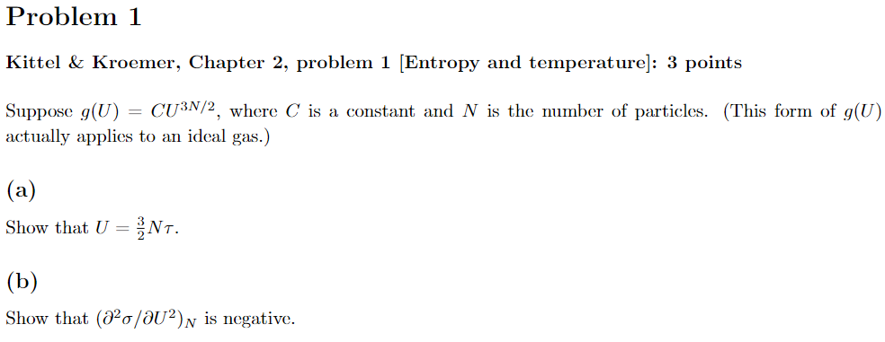

**Problem 1**

(a) $\sigma(U) = \ln(CU^{3N/2}) = \ln(C) + \frac{3N}{2}\ln(U)$

$$ \frac{1}{\tau} = \frac{\partial \sigma}{\partial U} = \frac{d}{dU} \ln\left(CU^{3N/2}\right) \\ \frac{1}{\tau} = \frac{3N}{2U} \\ U = \frac{3N}{2}\tau $$

(b) Just take the derivative of $\frac{3N}{2U}$

$$ \frac{\partial}{\partial U}\frac{3N}{2U} = -\frac{3N}{2U^2} $$

Since $N$ is positive, this must be negative

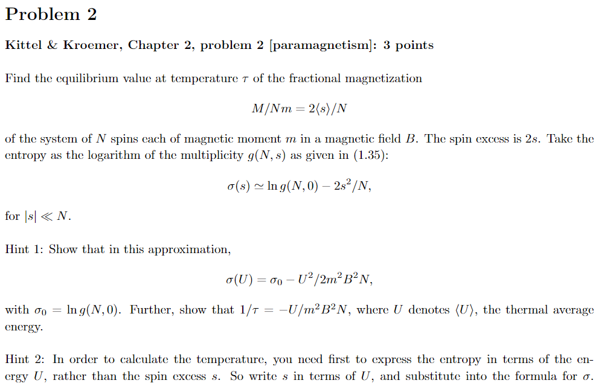

**Problem 2**

In this case $U = - MB$. This gives us

We can find $\tau$ pretty easily using

$$ \frac{1}{\tau} = \frac{\partial \sigma}{\partial U} $$

once we've worked in the relationship between $U$ and $s$.

$$ \frac{M}{m} = 2 \langle s \rangle $$

Since we're working out $\tau$ we can replace $\langle s \rangle$ with $s$, since $\langle s \rangle$ is the equilibrium, which depends on $\tau$

$$ M = -\frac{U}{B} \\ s = \frac{M}{2m} = -\frac{U}{2mB} \\ \sigma(U) = \sigma_0 - 2 \left(-\frac{U}{2mB} \right)^2/N \\ = \sigma_0 - \frac{U^2}{2m^2B^2N} \\ \frac{1}{\tau} = \frac{\partial \sigma}{\partial U} = - \frac{U}{m^2B^2N} \\ \tau = -\frac{m^2 B^2 N}{U} $$

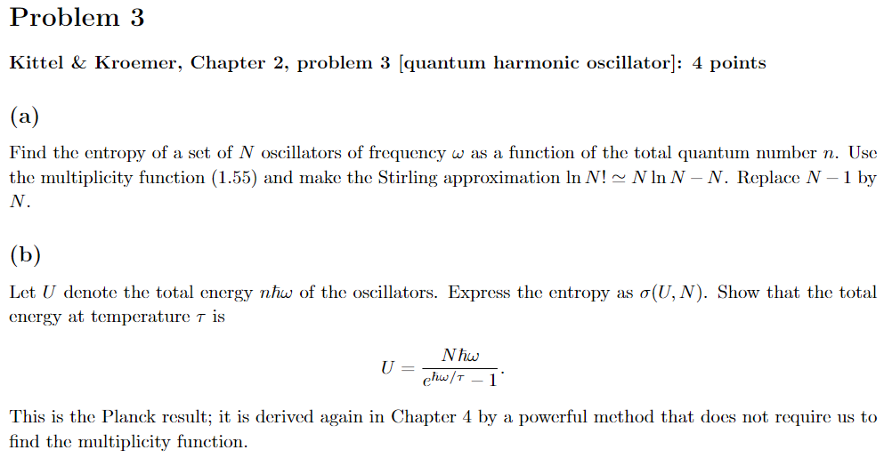

**Problem 3**

The entropy is just $\sigma = \ln(g)$. From 1.55 we have

$$ g(N,n) = \frac{(N+n-1)!}{n!(N-1)!} $$

which we adjust to $\frac{(N+n-1)!}{n!(N)!}$

$$ \sigma(N,n) = \ln(g(N,n)) = \ln\left(\frac{(N+n-1)!}{n!(N)!} \right) \\ = \ln((N+n-1)!) - \ln(n!) - \ln(N!) \\ = (N+n-1)\ln(N+n-1) - (N+n-1) - n\ln(n) +n - N\ln(N) + N \\ = (N+n-1)\ln(N+n-1) - n\ln(n) - N\ln(N) - 1 $$ Not sure quite how far we're going with this. $\ln(e) = 1$ $$ = \ln\left(\frac{(N+n-1)^{N+n-1}}{n^n N^N e} \right) $$

Energy $U=n\hbar \omega$. From this we can relate energy and total quantum number. Does $\sigma(U,N)$ and $\sigma(N,U)$ mean different things? I hope not

$$ n = \frac{U}{\hbar \omega} \\ \sigma(N,U) = \left(N+ \frac{U}{\hbar \omega}-1\right) \ln\left(N+ \frac{U}{\hbar \omega}-1\right) - \frac{U}{\hbar \omega} \ln \left(\frac{U}{\hbar \omega}\right) - N\ln(N) - 1 $$

How to get $U$ out of the logarithm? We can take the derivative and get $\tau$ first.

$$ \frac{1}{\tau} = \frac{\partial \sigma}{\partial U} = \frac{1}{\hbar \omega} \ln\left(N + \frac{U}{\hbar \omega}-1 \right) + \frac{1}{\hbar \omega} - \frac{1}{\hbar \omega}\log\left(\frac{U}{\hbar \omega} \right) - \frac{1}{\hbar \omega} \\ \frac{\hbar \omega}{\tau} = \ln\left(\frac{N+\frac{U}{\hbar \omega}}{\frac{U}{\hbar \omega}} \right) $$ Alright this I can work with $$ e^{\hbar \omega / \tau} = \frac{N}{\frac{U}{\hbar \omega}} + 1 \\ U = \frac{N\hbar \omega}{e^{\hbar \omega/\tau}-1} $$

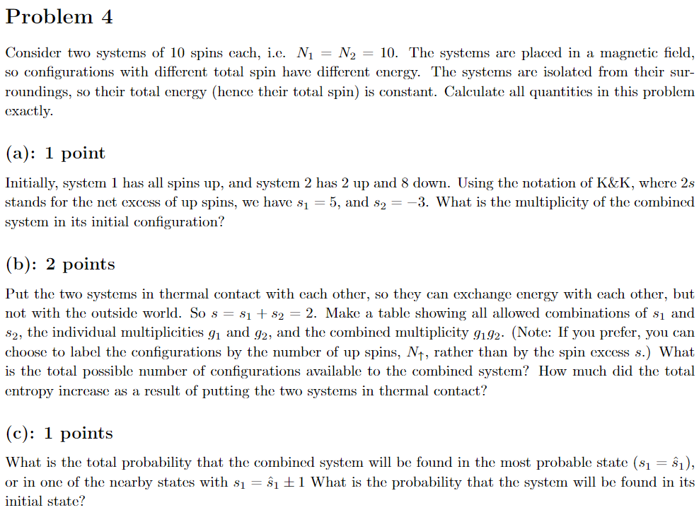

**Problem 4**

(a) Just use the multiplicity formula. $g_{tot} = g_1 g_2$

$$ g(N,s) = \frac{N!}{(N/2 + s)!(N/2-s)!} = \frac{N!}{N_\uparrow!N_\downarrow!} \\ g(10,5) = 1 \\ g(10,-3) = \frac{10!}{2!8!} = 45 \\ g_{tot} = 45 $$

(b) No better way than using code! Looks like entropy more than doubles compared to the initial state

```python
import pandas as pd
import numpy as np
from scipy.special import factorial

s1 = np.arange(-3, 6)
s2 = 2 - s1
g1 = factorial(10)/(factorial(5+s1)*factorial(5-s1))
g2 = factorial(10)/(factorial(5+s2)*factorial(5-s2))
gtot = g1*g2
entropy = np.log(gtot)

table = pd.DataFrame({'s1':s1, 's2':s2, 'g1':g1, 'g2':g2, 'total multiplicity':gtot, 'combined entropy':entropy})
table
```

|  | s1 | s2 | g1 | g2 | total multiplicity | combined entropy |
| --- | --- | --- | --- | --- | --- | --- |
| 0 | -3 | 5 | 45.0 | 1.0 | 45.0 | 3.806662 |
| 1 | -2 | 4 | 120.0 | 10.0 | 1200.0 | 7.090077 |
| 2 | -1 | 3 | 210.0 | 45.0 | 9450.0 | 9.153770 |
| 3 | 0 | 2 | 252.0 | 120.0 | 30240.0 | 10.316921 |
| 4 | 1 | 1 | 210.0 | 210.0 | 44100.0 | 10.694215 |
| 5 | 2 | 0 | 120.0 | 252.0 | 30240.0 | 10.316921 |
| 6 | 3 | -1 | 45.0 | 210.0 | 9450.0 | 9.153770 |
| 7 | 4 | -2 | 10.0 | 120.0 | 1200.0 | 7.090077 |
| 8 | 5 | -3 | 1.0 | 45.0 | 45.0 | 3.806662 |

(c) Probability is just # microstates/all possible states. It's more likely to be in the adjacent states rather than most probable state (2*24=48% vs 35%). The initial state is unlikely ~.04%

```python
table['probability'] = table['total multiplicity']/table['total multiplicity'].sum()
table
```

|  | s1 | s2 | g1 | g2 | total multiplicity | combined entropy | probability |
| --- | --- | --- | --- | --- | --- | --- | --- |
| 0 | -3 | 5 | 45.0 | 1.0 | 45.0 | 3.806662 | 0.000357 |
| 1 | -2 | 4 | 120.0 | 10.0 | 1200.0 | 7.090077 | 0.009526 |
| 2 | -1 | 3 | 210.0 | 45.0 | 9450.0 | 9.153770 | 0.075018 |
| 3 | 0 | 2 | 252.0 | 120.0 | 30240.0 | 10.316921 | 0.240057 |
| 4 | 1 | 1 | 210.0 | 210.0 | 44100.0 | 10.694215 | 0.350083 |
| 5 | 2 | 0 | 120.0 | 252.0 | 30240.0 | 10.316921 | 0.240057 |
| 6 | 3 | -1 | 45.0 | 210.0 | 9450.0 | 9.153770 | 0.075018 |
| 7 | 4 | -2 | 10.0 | 120.0 | 1200.0 | 7.090077 | 0.009526 |
| 8 | 5 | -3 | 1.0 | 45.0 | 45.0 | 3.806662 | 0.000357 |

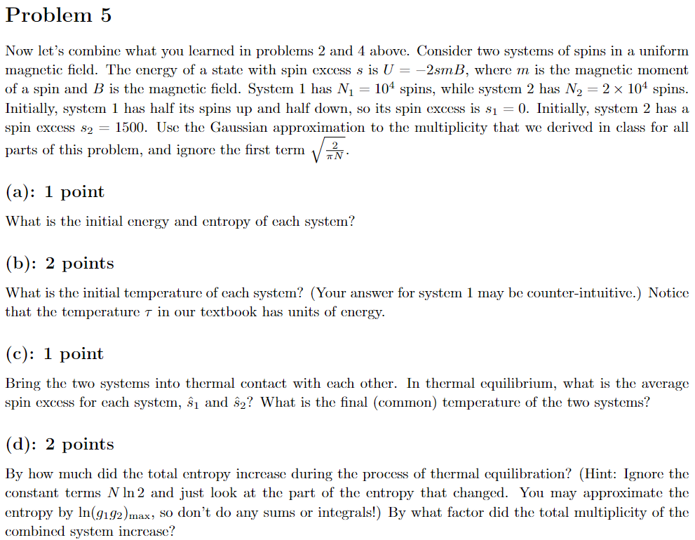

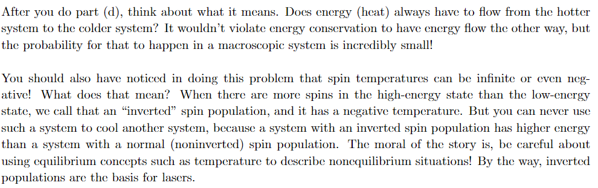

**Problem 5**

(a)

Energy: $U_1 + U_2 = -2(0)mB - 2(1500)mB = -3000mB$

Entropy: Let's set up the gaussian approximation. Getting rid of $\sqrt{\frac{2}{\pi N}}$ (still has the $2^N$ term)

$$ g(N,s) \approx 2^N e^{-2s^2/N} \\ \sigma(N,s) = \ln(g(N,s)) = \ln(2^N) + \ln(e^{-2s^2/N}) \\ = N\ln(2) - \frac{2s^2}{N} $$

Entropy adds, so our entropy is

$$ \sigma_{tot} = \sigma(10^4,0) + \sigma(2\times 10^4, 1500) = 10^4 \ln(2)+ 2\times 10^4 \ln(2) - \frac{(1500)^2}{10^4} \\ \approx 20569 $$

Just realized that we're asked for each system, not combined.

$U_1 = 0,\ U_2 = -3000mB$  
$\sigma_1 \approx 6931,\ \sigma_2 \approx 13638$

```python
from numpy import log
print(10**4 * log(2), 2*10**4 * log(2) - (1500)**2/(10**4))
```

```
6931.471805599453 13637.943611198905
```

[output not shown]

(b)

Initial temp of each system depends on each $\sigma(N,s)$, which is converted to $\sigma(N,-\frac{U}{2mB})$. We can drop the $N\ln(2)$ term thanks to the derivative.

$$ \frac{1}{\tau} = \frac{\partial \sigma}{\partial U} = \frac{d}{dU} \frac{-2\left(-\frac{U}{2mB} \right)^2}{N} = \frac{-2}{4m^2B^2N}\frac{d}{dU} U^2 \\ = \frac{-U}{m^2B^2N} \\ \tau = -\frac{m^2B^2N}{U} = -\frac{m^2B^2N}{-2smB} = \frac{mBN}{2s} $$

$$ \tau_1 = mB 10^4/(2*0)??? \\ \tau_2 = mB (2*10^4)/(2*1500) \approx 6.7mB $$

I guess the temperature $\tau_1$ is infinite

(c) Shouldn't spin excess be constant? Oh, you mean spins in each system. I'm guessing $\hat s_2 = 2\hat s_1$ since $N_2 = 2N_1$, but we'll see.

Equilibrium is when $\tau_1 = \tau_2$. $N$ and $S_{tot}$ are constant, only $s$ changes

$$ \tau_1 = \tau_2 \\ \frac{mB(10^4)}{2s_1} = \frac{mB(2\times 10^4)}{2s_2} \\ 2 s_2 = 2*2s_1 \\ s_2 = 2s_1 \checkmark \\ s_1 + s_2 = 1500 \rightarrow s_1 = 500,\ s_2 = 1000 \\ \tau = \frac{mB(10^4)}{2(500)} = 10mB $$

(d) I'll keep in the $N\ln(2)$ term so I can use my results from part (a)

$$ \sigma_1 = 10^4 \ln(2) - 2(500)^2/10^4 \approx 6881\\ \sigma_2 = 2\times10^4 \ln(2) - 2(1000)^2/(2\times10^4) \approx 13763 $$

Here's how entropy changed: $$ \sigma_1: 6931 \rightarrow 6881,\ \Delta \sigma_1 = -50 \\ \sigma_2: 13637 \rightarrow 13762,\ \Delta \sigma_2 = 125 \\ \Delta \sigma_{tot} = 75 $$

```python
print(10**4*log(2) - 2*(500)**2/10**4, 2*10**4*log(2) - 2*(1000)**2/(2*10**4))
```

```
6881.471805599453 13762.943611198905
```

In reflection, it looks like energy doesn't necessarily flow from high to low. If $m$ or $B$ have their sign flipped, the sign of energy is flipped, even if the sign of $\sigma$ isn't. It merely flows from low-likelyhood configuration to high-likelyhood configuration.